# rirods: A first release of a pure R package for iRODS

07 December, 2022

## iRODS + R

Background photo by [Alex Kondratiev](https://unsplash.com/@alexkondratiev?utm_source=unsplash&utm_medium=referral&utm_content=creditCopyText) on [Unsplash](https://unsplash.com/s/photos/lab?utm_source=unsplash&utm_medium=referral&utm_content=creditCopyText)

## Introduction to R

- Declarative programming centered around functions and logic (OOP capable)
- Emphasis on statistics and visualization of data
- Used by researchers and industry
- Open sourced, active useRs community (25610 packages)

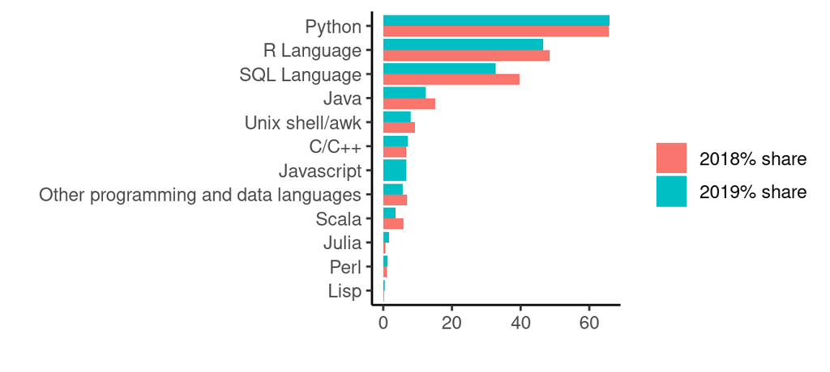

kdnuggets.com

## Why iRODS?

- R very powerful for creating reproducible workflows
  - Scripted analysis
  - Markdown (“Rmarkdown” + the new kid “Quarto”)
  - https://github.com/FAIReLABS/trirods_ugm2022

*Never again wonder what method did I use to center variable “foo” in my regression model … ?*

- But what about the data itself?
  - SQLite, MySQL, PostgreSQL, MonetDB with `DBI` package and ODBC drivers
  - iRODS?

Photo by [Tamanna Rumee](https://unsplash.com/photos/Px2K8O8dwa4?utm_source=unsplash&utm_medium=referral&utm_content=creditShareLink) on [Unsplash](https://unsplash.com/photos/Px2K8O8dwa4?utm_source=unsplash&utm_medium=referral&utm_content=creditShareLink)

## Opening-up the black box with iRODS + R

- Store unprocessed data
- Share data and scripts with collaborators
- Reviewer trace back the origin of data and imposed manipulations
- Publish everything = open science

[figure not shown]

[xkcd.com](https://xkcd.com/2582/)

## Design + Implementation

## The foundation

- Old R package build on the iRODS C++ API (archived)
- New R package build on the iRODS REST API
- https://github.com/irods/irods_client_library_rirods

## Global Design

- Functional style (modular build-up)
- Mimic iCommands
- Strictly user facing
- Interactive + batch scripts

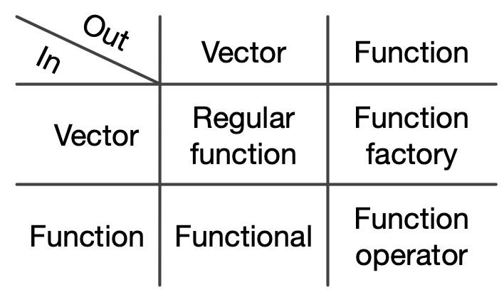

[Advanced R](https://adv-r.hadley.nz/fp.html) by Hadley Wickham

## Design

- Authentication
  - connect with iRODS server
  - authenticate

```r
# configuration file
create_irods("<host>", "<zone>")
# authenticate
iauth()
```

## Design

- Navigation
  - icommand like

```r
# current working collection
ipwd()
# change working collection
icd("<path>")
# list
ils()
```

## Design

- Objects/files
  - icommand like

```r
foo <- 1:10
# configuration file
iput(foo)
# authenticate
iget("foo")
# or
iget(foo) # ?
```

## Design

- Data discovery
  - imeta vs iquest

```r
# add some metadata
imeta(
  "foo",
  "data_object",
  operations =
    list(operation = "add", attribute = "foo", value = "bar", units = "baz")
)
# discover
iquery("SELECT COLL_NAME, DATA_NAME WHERE COLL_NAME LIKE '/tempZone/home/%'")
```

## Implementation

- Curl in R
  - R interface to libcurl *curl* (Ooms 2022a)
  - Wrapper *httr2* (Wickham 2022) for *curl* and *jsonlite* (Ooms 2022b)
- Development + Testing
  - irods demo server `docker-compose up -d nginx-reverse-proxy`
  - Testing with mocking *httptest2* (Richardson 2022)
  - Automatic updates of snapshots with GitHub actions
  - `R CMD check` without internet (simulate CRAN checks)

## Future plans

## Contribute

[interactive chart not shown]

## Roadmap

- Submission to CRAN
- Official release at UGM (summer 2023)
- More R packages: datamanager + panacaea

[figure not shown]

## FAIReLABS

**Help us!** https://fairelabs.github.io/webpage/

[interactive chart not shown]

## References

Ooms, Jeroen. 2022a. *Curl: A Modern and Flexible Web Client for r*. https://CRAN.R-project.org/package=curl.

———. 2022b. *Jsonlite: A Simple and Robust JSON Parser and Generator for r*. https://CRAN.R-project.org/package=jsonlite.

Richardson, Neal. 2022. *Httptest2: Test Helpers for Httr2*. https://CRAN.R-project.org/package=httptest2.

Wickham, Hadley. 2022. *Httr2: Perform HTTP Requests and Process the Responses*. https://CRAN.R-project.org/package=httr2.